Example 1 Home Example 3

© 2016 Jason Lomnitz. All rights reserved.

# Design Space Toolbox V2 Examples

## Example 2: Basic Analysis Part II

by Jason G. Lomnitz<sup>1</sup>

February 9<sup>th</sup>, 2016  
<sup>1</sup>Post-Doctoral Scholar, Department of Biomedical Engineering, University of California, Davis, CA 95616  
email:jason.lomnitz@gmail.com; phone:(530) 902 0421

This example is similar to the previous example, but demonstrates more advanced functions of the Design Space Toolbox.

This example has been created from the original examples for the matlab version of the design space toolbox, written by Rick Fasani.

## Import package with basic functionality

The initial step in running the design space toolbox is importing the base package, and in this case the plotting functionality.

```python
%matplotlib inline
```

Importing the plotting utilities subpackage adds plotting functions to objects object that are often of interest. We must also import the plotting library, and w make plotting interactive.

```python
import dspace
import dspace.plotutils
from math import *
from matplotlib.pyplot import *
matplotlib.interactive(True)
```

## Enter Equations

The following system is similar to the previous example, but with multiple negative terms. It still has two dependent variables and two independent variables, and the design space will vary over the two independent variables X3 and X4.

dX1/dt = 10*X1*X2*X3*X4 + X1*X2 - 10*X1*X3*X4^-1 - X1  
dX1/dt = (1/10)*X1*X2*X3*X4 + X1*X2 - (1/10)*X2*X3*X4^-1 - X2

Each equations in string format is entered forming a list of equations, where the left hand side of each equation is indicated by either the time-differentiated variable using dot notation for differentiation, or zero for constraint equations. An example of a algebraic constraint is shown for the system above.

dX1/dt = 10*X5 + X1*X2 - 10*X1*X3X4^-1 - X1  
dX1/dt = (1/10)X5 + X1*X2 - (1/10)*X2*X3*X4^-1 - X2 X5 = X1*X2*X3*X4

```python
f = ['X1. =     alpha*X5 + X1*X2 -     alpha*X1*X3*X4^-1 - X1',
     'X2. = (1/alpha)*X5 + X1*X2 - (1/alpha)*X2*X3*X4^-1 - X2',
     ' X5 = X1*X2*X3*X4']
```

The next step is to construct an Equations object using this list of strings and specifying which variables are auxiliary and thus dependent. These are specified by a list of variables names passed by the 'auxiliary_variables' keyword argument.

```python
eq = dspace.Equations(f, auxiliary_variables=['X5'])
```

## Construct the System Design Space

The previous system of equations can be analyzed using system design space. To construct the design space, we use an Equations object specifying our system.

```python
ds = dspace.DesignSpace(eq)
```

## Test for Validity

We choose X3 and X4 as are axes for a 2D plot, and must specify a value for alpha. We obtain the list of valid cases with a slice through design space with alpha = 10, 1e-3 < X3 < 1e3 and 1e-3 < X4 < 1e3.

```python
valid_cases = ds.valid_cases(p_bounds={'alpha':10,
                                       'X3':[1e-3, 1e3],
                                       'X4':[1e-3, 1e3]})

print 'All valid cases in slice: ' + str(valid_cases)
```

```
All valid cases in slice: ['1', '2', '3', '4', '6', '8', '11', '12', '16']
```

## Plot

We define a nominal point in parameter space.  
The value of the individual variables at this point will not affect the plots. We obtain the list of parameters and independent variables from the design space object.

```python
ivar_names = ds.independent_variables
```

We define a variable pool that holds symbols for all the independent variables and parameters of the system, by passing these names to the construction of the object.

```python
pvals = dspace.VariablePool(names=ivar_names)
pvals['alpha'] = 10
pvals['X3'] = 1  # Will be a variable on an axis, value wont be affect plot
pvals['X4'] = 1  # Will be a variable on an axis, value wont be affect plot
```

## Global color scheme for use across multiple slices.

In this example we will plot many different slices of the same dsign space. To get consistent colors for the different regions, we will use a global color scheme with all the valid cases included.

```python
all_valid_cases = ds.valid_cases()
colors = dict()
for i in range(0, len(all_valid_cases)):
    colors[str(all_valid_cases[i])] = matplotlib.cm.hsv(float(i)/len(all_valid_cases))

temp = colors['6']
colors['6'] = colors['11']
colors['11'] = temp
```

We make the design space object plot a 2D slice with a specified x and y axis and a reference parameter set. To make the colors consistent across the figures we have included the colors from the previous plot by passing a color dictionary to the 'color_dict' keyword argument in the drawing method.

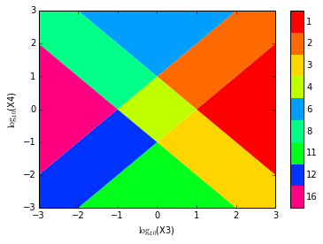

```python
fig = figure(1)
clf()
ax = gca()
ds.draw_2D_slice(ax,
                 pvals,             # Pass the reference parameter set.
                 'X3',              # First, indicate the x-axis variable.
                 'X4',              # Second, indicate the y-axis variable.
                 [1e-3, 1e3],       # The range on the x-axis.
                 [1e-3, 1e3],       # The range on the y-axis.
                 color_dict=colors, # Specify a color dictionary for the cases.
                 )
sca(ax)
```

## Obtaining the vertices in 2D

The verticesfor the 2D slice are obtained for case 4, the diamond in the center.

```python
case4 = ds(4)
vertices = case4.vertices_2D_slice(pvals, 'X3', 'X4')
print vertices
```

```
[[10.0, 1.0], [1.0, 0.1], [0.1, 1.0], [1.0, 10.0]]
```

## Create a Bounding Box in higher domensions

```python
box = case4.bounding_box(log_out=True)
print box
```

```
{'alpha': [0.0, 15.0], 'X4': [-15.0, 15.0], 'X3': [-15.0, 15.0]}
```

A bounding box can be obtained with specific constraints on the parameters, by passing parameter values or parameter ranges.

```
{'X3': [-1.0, 1.0], 'X4': [-1.0, 1.0]}
```

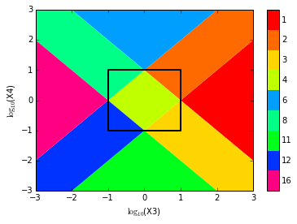

```python
fig = figure(1)
clf()
ax = gca()
ds.draw_2D_slice(ax,
                 pvals,             # Pass the reference parameter set.
                 'X3',              # First, indicate the x-axis variable.
                 'X4',              # Second, indicate the y-axis variable.
                 [1e-3, 1e3],       # The range on the x-axis.
                 [1e-3, 1e3],       # The range on the y-axis.
                 color_dict=colors, # Specify a color dictionary for the cases.
                 )
sca(ax)

box = case4.bounding_box(p_bounds={'alpha':10,
                                   'X3':[1e-3, 1e3],
                                   'X4':[1e-3, 1e3]},
                         log_out=True);
print box

x_vertices = [min(box['X3']), min(box['X3']),max(box['X3']), max(box['X3'])]
y_vertices = [min(box['X4']), max(box['X4']), max(box['X4']), min(box['X4'])]
fill(x_vertices, y_vertices,facecolor='none', edgecolor='k', linewidth=2.)
```

The box is plotted in the previous figure, where the bounds (in logarithmic coordinates) can be visually confirmed.

## Measure Tolerance

An operating point is set such that it is in case 4.

```python
pvals['X3'] = 2
pvals['X4'] = 1
```

```python
tol = case4.measure_tolerance(pvals, log_out=True);
print tol
```

```
{'alpha': (-0.6989700043360187, 19.0), 'X4': (-0.6989700043360187, 0.6989700043360187), 'X3': (-1.3010299956639813, 0.6989700043360187)}
```

The operating point is plotted and the tolerance (in logarithmic coordinates) can be visually confirmed. We make a new plot with only the case of interest, and overlay the operating point and measured tolerances.

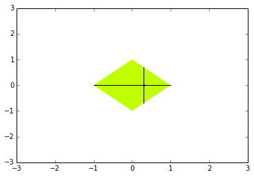

```python
figure(2)
clf()
ax = gca()
case4.draw_2D_slice(ax, pvals, 'X3', 'X4', [1e-3, 1e3], [1e-3, 1e3],
                    facecolor=colors['4'], edgecolor='none')
xlim(-3, 3)
ylim(-3, 3)

# Plot the operating point as a black point.

plot(log10(pvals['X3']), log10(pvals['X4']), 'k.')

# Plot the tolerances as two lines using list enumeration.

plot([log10(pvals['X3'])]*2,
     [i+log10(pvals['X4']) for i in tol['X4']], 'k')
plot([i+log10(pvals['X3']) for i in tol['X3']],
     [log10(pvals['X4'])]*2, 'k')
```

## Plot Multiple Cases

The design space is plotted for two cases: alpha = 10 and alpha = 1/10.

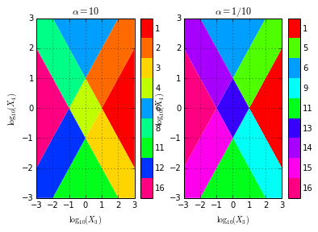

```python
fig = figure(3)
clf()

ax1 = fig.add_subplot(121)
pvals['alpha'] = 10
ds.draw_2D_slice(ax1, pvals, 'X3', 'X4', [1e-3, 1e3], [1e-3, 1e3],
                 color_dict=colors)
sca(ax1)
xlabel(r'$\log_{10}(X_3)$');
ylabel(r'$\log_{10}(X_4)$');
title(r'$\alpha = 10$');
grid(True);

ax2 = fig.add_subplot(122)
pvals['alpha'] = 1./10
ds.draw_2D_slice(ax2, pvals, 'X3', 'X4', [1e-3, 1e3], [1e-3, 1e3],
                 color_dict=colors)
sca(ax2)
xlabel(r'$\log_{10}(X_3)$');
ylabel(r'$\log_{10}(X_4)$');
title(r'$\alpha = 1/10$');
grid(True);
```

## Plot 3D Slice

A plot with alpha changing from 10 to 1/10, X3, and X4 produce a 3-D image that can be constructed and manipulated using th plot utilities. First we must import the 3D plotting component of matplotlib.

```python
from mpl_toolkits.mplot3d import Axes3D
import mpl_toolkits.mplot3d as a3
```

We make the design space object plot the 3D slice a specified x, y and z axes with reference parameter set.

[output not shown]

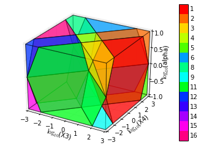

```python
fig = figure(4)
clf()

ax = fig.add_subplot('111', projection='3d')       # We define the plot axes where it will be drawn.
ds.draw_3D_slice(ax,
                 pvals,       # Pass the reference parameter set.
                 'X3',        # First, indicate the x-axis variable.
                 'X4',        # Second, indicate the y-axis variable.
                 'alpha',     # Thir, indicate the z-axis variable.
                 [1e-3, 1e3], #Indicate the range on the x-axis.
                 [1e-3, 1e3], #Indicate the range on the y-axis.
                 [1e-1, 1e1], #Indicate the range on the z-axis.
                 color_dict=colors
                )
```

Example 1 Home Example 3